# Tugas 1 — Pengantar Analisis Data Kategori

Latihan Analisis Data dengan R dan Quarto

Mahasiswa

Aisyah Fadhillah Muhammad Azis

NIM

241061013

Kode Tugas

ADK1-07018231

**Tujuan tugas.** Gunakan kembali konsep dan fungsi R yang telah dibahas pada Pertemuan 1 untuk mengenali struktur data kategori, membuat ringkasan deskriptif, memvisualisasikan data, dan menjelaskan insight secara hati-hati.

**CatatanPola kerja**

Ikuti pola kelas: **predict → run → inspect → explain**.

Pada setiap bagian diberikan **sedikit petunjuk kode**.  
Jika diminta menjelaskan atau menuliskan interpretasi, gunakan kotak **Jawaban Anda** yang telah disediakan.

# 1 1. Mengenali Data

Gunakan R untuk melihat beberapa baris awal, struktur data, dan nama variabel.

**TipPetunjuk kode**

```r
head(...)
str(...)
names(...)
```

Ganti `...` dengan objek data yang digunakan.

```r
# Tulis kode Anda di sini
data_tugas <- read.csv(
  "data_tugas1_241061013.csv",
  na.strings = c("", "NA"),
  stringsAsFactors = FALSE
)

head(data_tugas)
```

```
  RecordID     ProgramStudi Gender DeviceUtama ModaBelajar    Kepuasan
1   849870       Matematika      P      Tablet        Buku Sangat Puas
2   347917       Matematika      P      Laptop     Diskusi        Puas
3   402953 Sistem Informasi      P      Laptop        Buku        Puas
4   889016       Sains Data      P  Smartphone     Praktik        Puas
5   195099       Sains Data      L      Tablet     Praktik  Tidak Puas
6   834102       Sains Data      P      Laptop     Praktik        <NA>
  IntensitasBelajar DurasiBelajarJam       PaketID
1            Rendah              5.7 ADK1-07018231
2            Tinggi             10.2 ADK1-07018231
3            Sedang              8.2 ADK1-07018231
4            Sedang              6.2 ADK1-07018231
5            Tinggi             12.0 ADK1-07018231
6            Sedang              8.7 ADK1-07018231
```

```r
str(data_tugas)
```

```
'data.frame':   112 obs. of  9 variables:
 $ RecordID         : int  849870 347917 402953 889016 195099 834102 577636 666768 196924 633242 ...
 $ ProgramStudi     : chr  "Matematika" "Matematika" "Sistem Informasi" "Sains Data" ...
 $ Gender           : chr  "P" "P" "P" "P" ...
 $ DeviceUtama      : chr  "Tablet" "Laptop" "Laptop" "Smartphone" ...
 $ ModaBelajar      : chr  "Buku" "Diskusi" "Buku" "Praktik" ...
 $ Kepuasan         : chr  "Sangat Puas" "Puas" "Puas" "Puas" ...
 $ IntensitasBelajar: chr  "Rendah" "Tinggi" "Sedang" "Sedang" ...
 $ DurasiBelajarJam : num  5.7 10.2 8.2 6.2 12 8.7 8.3 6.7 5 9.2 ...
 $ PaketID          : chr  "ADK1-07018231" "ADK1-07018231" "ADK1-07018231" "ADK1-07018231" ...
```

```r
names(data_tugas)
```

```
[1] "RecordID"          "ProgramStudi"      "Gender"
[4] "DeviceUtama"       "ModaBelajar"       "Kepuasan"
[7] "IntensitasBelajar" "DurasiBelajarJam"  "PaketID"
```

Lengkapi tabel berikut.

| Variabel | Jenis Variabel | Alasan Singkat |
| --- | --- | --- |
| RecordID | Identifier | Sebagai identitas unik setiap record |
| ProgramStudi | Nominal | Tidak memiliki urutan atau tingkatan |
| Gender | Nominal | Tidak memiliki urutan atau tingkatan |
| DeviceUtama | Nominal | Tidak memiliki urutan atau tingkatan |
| ModaBelajar | Nominal | Tidak memiliki urutan atau tingkatan |
| Kepuasan | Ordinal | Memiliki urutan atau tingkatan |
| IntensitasBelajar | Ordinal | Memiliki urutan atau tingkatan |
| DurasiBelajarJam | Numerik (Rasio) | Menunjukkan jumlah durasi dalam jam |

Jawab singkat:

1. Variabel mana yang merupakan identifier?
2. Variabel mana yang bersifat ordinal?
3. Mengapa kode angka belum tentu berarti data numerik?

**Jawaban Anda**

1. RecordID, karena digunakan sebagai identitas unik setiap record.
2. Kepuasan dan IntensitasBelajar, karena memiliki urutan atau tingkatan.
3. Karena angka juga dapat digunakan sebagai kode kategori, bukan hanya sebagai nilai yang memiliki makna matematis.

# 2 2. Menyiapkan Data Kategori

Variabel latihan Anda:

```r
cat("Nominal :", identitas$nominal_utama[1], "\n")
```

```
Nominal : ProgramStudi
```

```r
cat("Ordinal :", identitas$ordinal_utama[1], "\n")
```

```
Ordinal : IntensitasBelajar
```

```r
cat("Urutan  :", identitas$urutan_ordinal[1], "\n")
```

```
Urutan  : Rendah|Sedang|Tinggi
```

Lakukan hal berikut:

1. ubah variabel nominal menjadi factor;
2. ubah variabel ordinal menjadi ordered factor;
3. periksa level kategorinya.

**TipPetunjuk kode**

Untuk nominal:

```r
factor(...)
levels(...)
```

Untuk ordinal:

```r
factor(..., levels = ..., ordered = TRUE)
```

```r
nominal_var <- identitas$nominal_utama[1]
ordinal_var <- identitas$ordinal_utama[1]
urutan <- strsplit(identitas$urutan_ordinal[1], "\\|")[[1]]

# Tulis kode Anda di bawah ini
data_tugas[[nominal_var]] <- factor(data_tugas[[nominal_var]])

data_tugas[[ordinal_var]] <- factor(
  data_tugas[[ordinal_var]],
  levels = urutan,
  ordered = TRUE
)

levels(data_tugas[[nominal_var]])
```

```
[1] "Matematika"       "Sains Aktuaria"   "Sains Data"       "Sistem Informasi"
```

```r
levels(data_tugas[[ordinal_var]])
```

```
[1] "Rendah" "Sedang" "Tinggi"
```

Tuliskan satu kalimat: **mengapa urutan level ordinal perlu ditetapkan dengan benar?**

**Jawaban Anda**

Agar R mengenali tingkatan kategori sesuai dengan urutan yang sebenarnya.

# 3 3. Quality Control Awal

Lakukan pemeriksaan sederhana terhadap:

- struktur data;
- level/kategori;
- missing value;
- konsistensi penulisan kategori.

**TipPetunjuk kode**

Beberapa pola fungsi yang dapat digunakan:

```r
str(...)
levels(...)
unique(...)
is.na(...)
colSums(...)
```

Pilih fungsi yang sesuai dengan tujuan pemeriksaan Anda.

```r
# Tulis kode Anda di sini

# Struktur data
str(data_tugas)
```

```
'data.frame':   112 obs. of  9 variables:
 $ RecordID         : int  849870 347917 402953 889016 195099 834102 577636 666768 196924 633242 ...
 $ ProgramStudi     : Factor w/ 4 levels "Matematika","Sains Aktuaria",..: 1 1 4 3 3 3 2 3 2 4 ...
 $ Gender           : chr  "P" "P" "P" "P" ...
 $ DeviceUtama      : chr  "Tablet" "Laptop" "Laptop" "Smartphone" ...
 $ ModaBelajar      : chr  "Buku" "Diskusi" "Buku" "Praktik" ...
 $ Kepuasan         : chr  "Sangat Puas" "Puas" "Puas" "Puas" ...
 $ IntensitasBelajar: Ord.factor w/ 3 levels "Rendah"<"Sedang"<..: 1 3 2 2 3 2 3 2 1 2 ...
 $ DurasiBelajarJam : num  5.7 10.2 8.2 6.2 12 8.7 8.3 6.7 5 9.2 ...
 $ PaketID          : chr  "ADK1-07018231" "ADK1-07018231" "ADK1-07018231" "ADK1-07018231" ...
```

```r
# Level/kategori
levels(data_tugas[[nominal_var]])
```

```
[1] "Matematika"       "Sains Aktuaria"   "Sains Data"       "Sistem Informasi"
```

```r
levels(data_tugas[[ordinal_var]])
```

```
[1] "Rendah" "Sedang" "Tinggi"
```

```r
# Missing value
colSums(is.na(data_tugas))
```

```
         RecordID      ProgramStudi            Gender       DeviceUtama
                0                 0                 0                 2
      ModaBelajar          Kepuasan IntensitasBelajar  DurasiBelajarJam
                0                 2                 1                 0
          PaketID
                0
```

```r
# Konsistensi penulisan kategori
unique(data_tugas[[nominal_var]])
```

```
[1] Matematika       Sistem Informasi Sains Data       Sains Aktuaria
Levels: Matematika Sains Aktuaria Sains Data Sistem Informasi
```

```r
unique(data_tugas[[ordinal_var]])
```

```
[1] Rendah Tinggi Sedang <NA>
Levels: Rendah < Sedang < Tinggi
```

Tuliskan **dua temuan singkat** dari pemeriksaan tersebut.

**Jawaban Anda**

1. Data terdiri dari 112 observasi dan 9 variabel. ProgramStudi sudah bertipe factor dan IntensitasBelajar sudah menjadi ordered factor dengan urutan Rendah < Sedang < Tinggi.
2. Ditemukan 5 missing value, yaitu pada DeviceUtama sebanyak 2, Kepuasan sebanyak 2, dan IntensitasBelajar sebanyak 1. Selain itu, Tidak terlihat variasi penulisan kategori yang tidak konsisten.

# 4 4. Frekuensi dan Proporsi

Sebelum menjalankan kode, prediksi:

> Menurut Anda, kategori mana yang paling banyak muncul pada variabel nominal Anda?

**Prediksi Anda**

Saya memperkirakan kategori Matematika akan memiliki frekuensi paling banyak.

Setelah itu, buat:

- tabel frekuensi untuk variabel nominal;
- proporsi untuk variabel ordinal.

**TipPetunjuk kode**

```r
table(...)
prop.table(...)
```

Anda dapat menyimpan hasil `table()` ke sebuah objek terlebih dahulu sebelum menghitung proporsi.

```r
# Tulis kode Anda di sini
# Frekuensi variabel nominal
freq_nominal <- table(data_tugas[[nominal_var]])
freq_nominal
```

```
      Matematika   Sains Aktuaria       Sains Data Sistem Informasi
              35               21               28               28
```

```r
# Proporsi variabel ordinal
prop_ordinal <- prop.table(table(data_tugas[[ordinal_var]]))
prop_ordinal
```

```
   Rendah    Sedang    Tinggi
0.3423423 0.3333333 0.3243243
```

Tuliskan **dua kalimat insight** berdasarkan output.

**Interpretasi Anda**

1. ProgramStudi dengan frekuensi terbesar adalah Matematika, yaitu sebanyak 35 observasi.
2. Proporsi IntensitasBelajar paling banyak berada pada kategori Rendah, sedangkan yang paling sedikit berada pada kategori Tinggi.

# 5 5. Tabel Silang

Pasangan variabel Anda:

```r
x <- identitas$tab_baris[1]
y <- identitas$tab_kolom[1]

cat("Baris :", x, "\n")
```

```
Baris : ProgramStudi
```

```r
cat("Kolom :", y, "\n")
```

```
Kolom : IntensitasBelajar
```

Buat tabel silang untuk kedua variabel tersebut.

Jika diperlukan, tampilkan proporsi per baris untuk membantu membaca pola.

**TipPetunjuk kode**

```r
table(..., ...)
prop.table(..., margin = 1)
```

Lengkapi sendiri objek yang diperlukan.

```r
# Tulis kode Anda di sini
# Menentukan variabel baris dan kolom
x <- identitas$tab_baris[1]
y <- identitas$tab_kolom[1]

cat("Baris :", x, "\n")
```

```
Baris : ProgramStudi
```

```r
cat("Kolom :", y, "\n")
```

```
Kolom : IntensitasBelajar
```

```r
# Membuat tabel silang
tab_silang <- table(data_tugas[[x]], data_tugas[[y]])
tab_silang
```

```
                   Rendah Sedang Tinggi
  Matematika           13      9     13
  Sains Aktuaria        7      4     10
  Sains Data            9     12      7
  Sistem Informasi      9     12      6
```

```r
# Proporsi per baris
prop_baris <- prop.table(tab_silang, margin = 1)
prop_baris
```

```
                      Rendah    Sedang    Tinggi
  Matematika       0.3714286 0.2571429 0.3714286
  Sains Aktuaria   0.3333333 0.1904762 0.4761905
  Sains Data       0.3214286 0.4285714 0.2500000
  Sistem Informasi 0.3333333 0.4444444 0.2222222
```

Tuliskan **satu kalimat** yang menjelaskan pola yang tampak.

**Interpretasi Anda**

IntensitasBelajar cenderung berbeda antar ProgramStudi, dengan kategori Tinggi paling banyak pada Sains Aktuaria dan kategori Sedang pada Sains Data serta Sistem Informasi. Sedangkan Matematika memiliki proporsi Rendah dan Tinggi yang sama.

**Penting**

Gunakan bahasa deskriptif. Jangan langsung menyimpulkan adanya hubungan signifikan atau sebab-akibat.

# 6 6. Visualisasi Kategorik

Variabel yang divisualisasikan:

```r
v <- identitas$visualisasi[1]
cat("Variabel grafik :", v, "\n")
```

```
Variabel grafik : IntensitasBelajar
```

Buat **satu grafik batang** seperti yang telah dipelajari pada Pertemuan 1.

**TipPetunjuk kode**

```r
library(ggplot2)

ggplot(..., aes(x = ...)) +
  geom_bar() +
  labs(...)
```

Sesuaikan objek data, variabel, judul, dan label sumbu.

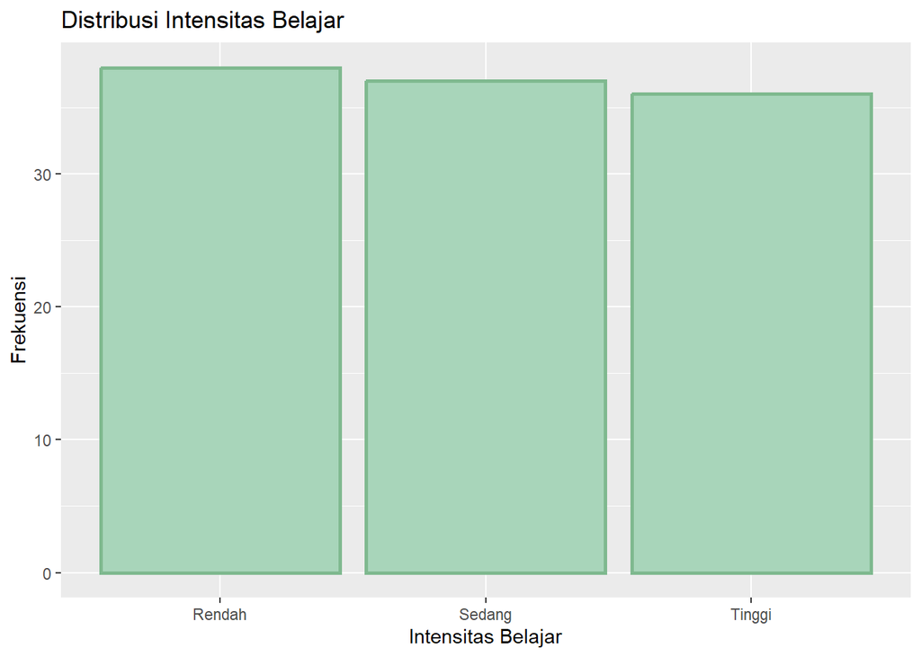

```r
# Tulis kode Anda di sini
library(ggplot2)

v <- identitas$visualisasi[1]

ggplot(
  data_tugas[!is.na(data_tugas[[v]]), ],
  aes(x = .data[[v]])
) +
  geom_bar(
    fill = "#A8D5BA",
    color = "#7FB98F",
    linewidth = 1
  ) +
  labs(
    title = "Distribusi Intensitas Belajar",
    x = "Intensitas Belajar",
    y = "Frekuensi"
  )
```

Tuliskan **satu kalimat** interpretasi grafik.

**Interpretasi Anda**

Grafik menunjukkan bahwa kategori Rendah memiliki frekuensi tertinggi, sedangkan kategori Tinggi memiliki frekuensi terendah pada IntensitasBelajar.

# 7 7. Kesimpulan

Tuliskan **3 poin kesimpulan singkat** berdasarkan hasil analisis.

Setiap kesimpulan harus:

- didukung oleh output yang telah Anda hasilkan;
- menggunakan angka yang relevan;
- ditulis dengan bahasa Anda sendiri;
- tidak menggunakan klaim sebab-akibat.

**Kesimpulan Anda**

1. Dataset yang dianalisis terdiri atas 112 observasi, 9 variabel, dan 5 nilai missing.
2. Pada ProgramStudi, Matematika memiliki jumlah terbanyak, yaitu 35, sedangkan Sains Aktuaria memiliki jumlah paling sedikit, yaitu 21.
3. Untuk IntensitasBelajar, kategori Rendah memiliki proporsi sebesar 0,3423, sedangkan kategori Tinggi memiliki proporsi sebesar 0,3243.

**Analisis Data Kategori — Tugas 1**  
Predict → Run → Inspect → Explain